# Metadata maices

Idalia Rojas

2025-06-24

# Tablas de metadatos y construcción de subconjunto de datos

Dependencias en bash: - vcftools - plink - tabix

Librerias en R: - kniitr - kableExtra - tidyr - dplyr - tidyverse

Si los directorios **`meta`** **`subset`** no existen en tu directorio de trabajo, crealos con el siguiente comando:

```r
#system('mkdir ./meta')
#system('mkdir ./subset')
```

### Cargar archivos en Rstudio

En este caso, emplearemos **datos** públicos de un estudio publicado en 2019, que empleó datos genómicos de **razas** de **maíz** para evaluar la evolución de este cultivo en México, donde se encuentra el centro de origen y diversidad para este cultivo.

El artículo [*Contemporary evolution of maize landraces and their wild relatives influenced by gene flow with modern maize varieties*](https://www.pnas.org/doi/full/10.1073/pnas.1817664116) puede ser consultado en este [enlace](https://www.pnas.org/doi/full/10.1073/pnas.1817664116), y los datos genómicos y metadatos están disponibles en el repositorio de [OSF](https://osf.io/pqvt4/).

```r
genotipos <-read.delim("./meta/metadata_385_taxa_Rojas_etal_2019.txt", sep = "\t")

accesiones <- read.delim( "./meta/Samples_and_Accessions.csv", sep = "\t",skip = 6)

kable(head(genotipos, 3), align = "c") %>%
  kable_styling(full_width = FALSE)
```

| bam_file_list | vcf_list | sample_explanation_pop_explanation | groups | altitud |
| --- | --- | --- | --- | --- |
| ./bam/10026_1:C7U03ANXX:7:250516166.sort.bam | 10026_1:C7U03ANXX:7:250516166 | ZmTm198304_ZmTm1983 | Zmx1980 | 1800 |
| ./bam/10026_2:C7U03ANXX:7:250516174.sort.bam | 10026_2:C7U03ANXX:7:250516174 | ZmTm198302_ZmTm1983 | Zmx1980 | 1800 |
| ./bam/10026_3:C7U03ANXX:7:250516182.sort.bam | 10026_3:C7U03ANXX:7:250516182 | ZmTm198303_ZmTm1983 | Zmx1980 | 1800 |

```r
kable(head(accesiones, 3), align = "c") %>%
  kable_styling(full_width = FALSE)
```

| Accesion_ID | Locality | State | Accesion_Germplasm_Bank_ID | Longitude | Latitude | Altitude_masl | N |
| --- | --- | --- | --- | --- | --- | --- | --- |
| AmTp2015(1) | Amatlán de Quetzalcóatl | Morelos | Zea mays ssp. parviglumis allopatric 2015 | -99.03408 | 18.98203 | 1678 | 5 |
| BoH12015 | San Cristobal Honduras | Oaxaca | Modern Variety | -97.02734 | 16.32723 | 1280 | 5 |
| BoNa1943 | San Miguel Etla | Oaxaca | Bolita 1943 (CIMMYT 2267) | -96.78517 | 17.20730 | 1684 | 6 |

### Editar las tablas de datos

Extracción de los IDs para armar un subconjunto de datos con los maíces, excluyendo a los parientes silvestres. Es posible emplear los comandos de Bash dentro de un script de R. Para ello debemos usar el comando **`system`** y escribir el comando de Bash entre comillas.

```r
#Usar un comando de bash en R
system("bcftools query -l ../../data/Zea_mays.AGPv4.2x_0.8_0.01.NewID.Rojas2019.recode.vcf > ./meta/genotypes_vcf.txt")

#Cargar el set de datos extraído del archivo VCF y asignar nombres a las columnas
IDs<- read.delim("./meta/genotypes_vcf.txt", sep = "_", header = FALSE)
kable(head(IDs, 5), align = "c") %>%
  kable_styling(full_width = FALSE)
```

| V1 | V2 |
| --- | --- |
| ZmTm198304 | ZmTm1983 |
| ZmTm198302 | ZmTm1983 |
| ZmTm198303 | ZmTm1983 |
| TbTp198304 | TbTp1983 |
| ChTm198404 | ChTm1984 |

Esta es la manera en que lucen los IDs de los genotipos extraidos de un archivo VCF. En este caso la columna 1 repesenta el ID-unico del genotipo y la columna 2 el nombre de la accesion a la que esta asignado ese genotipo.

Ahora asignaremos nombres a las columnas de los IDs extraidos: **`Genotipo`** y **`Accesion_ID`**

```r
colnames(IDs) <- c("Genotipo", "Accesion_ID")

#Extraer la información contenida en la columna de Accesion_ID
extract <- IDs %>% separate(Accesion_ID,
                       into = c("Raza", "Cultivar", "Anio_colecta"),
                       sep = c(2,4,8))
#Merge our new information
IDs<- merge(IDs, extract, by = "Genotipo")
kable(head(IDs, 5), align = "c") %>%
  kable_styling(full_width = FALSE)
```

| Genotipo | Accesion_ID | Raza | Cultivar | Anio_colecta |
| --- | --- | --- | --- | --- |
| AmTp201501 | AmTp2015 | Am | Tp | 2015 |
| AmTp201503 | AmTp2015 | Am | Tp | 2015 |
| AmTp201504 | AmTp2015 | Am | Tp | 2015 |
| AmTp201505 | AmTp2015 | Am | Tp | 2015 |
| AmTp20152b | AmTp2015 | Am | Tp | 2015 |

Una vez extraída la información hagamos un subconjunto unicamente con los genotipos de maíces. La abreviatura **`Na`** en la columna **`Cultivar`** hace referencia a maices nativos.

```r
maices <- IDs[IDs$Cultivar == "Na",]

#Verifica cuantas razas de maiz tenemos en el set de datos
razas <- levels(factor(maices$Raza))
nrazas <- nlevels(factor(maices$Raza))
print(paste("Nuestro conjunto de datos contiene los genotipos para", nrazas, "razas:", toString(razas)))
```

```
## [1] "Nuestro conjunto de datos contiene los genotipos para 7 razas: Bo, Ch, Ms, Pp, Tb, Va, Zm"
```

```r
kable(head(maices, 5), align = "c") %>%
  kable_styling(full_width = FALSE)
```

|  | Genotipo | Accesion_ID | Raza | Cultivar | Anio_colecta |
| --- | --- | --- | --- | --- | --- |
| 11 | BoNa194301 | BoNa1943 | Bo | Na | 1943 |
| 12 | BoNa194302 | BoNa1943 | Bo | Na | 1943 |
| 13 | BoNa194303 | BoNa1943 | Bo | Na | 1943 |
| 14 | BoNa194304 | BoNa1943 | Bo | Na | 1943 |
| 15 | BoNa194305 | BoNa1943 | Bo | Na | 1943 |

Ahora vamos a sustituir los nombres abreviados de las razas por los nombres en extenso empleando la siguiente clave:

| Abreviatura | Nombre.en.extenso |
| --- | --- |
| Bo | Bonito |
| Ch | Chalqueno |
| Ms | Mushito |
| Pp | Pepitilla |
| Tb | Tabloncillo |
| Va | Vandeno |
| Zm | Zamorano |

Crea la columna **`Extenso`** y sustituye las abreviaturas con los nombres dados en la tabla anterior.

```r
maices$Extenso <- maices$Raza

#Sustituir los valores
maices$Extenso <- recode(maices$Extenso, Bo = "Bonito", Ch = "Chalqueno",
                         Ms = "Mushito", Pp= "Pepitilla", Tb = "Tabloncillo",
                         Va = "Vandeno", Zm = "Zamorano")
```

### Subconjunto de datos con 50 genotipos

El subset de datos con maíces esta integrado por 186 genotipos, para reducir el tiempo de computo y el tamaño de los archivos generaremos una **lista con 50 genotipos**, para ello usaremos la función de R **`sample.`**

```r
set.seed(123)  # For reproducibility
maices_slice <- maices[sample(nrow(maices), 50), ]
kable(head(maices_slice,5), align = "c") %>%
  kable_styling(full_width = FALSE)
```

|  | Genotipo | Accesion_ID | Raza | Cultivar | Anio_colecta | Extenso |
| --- | --- | --- | --- | --- | --- | --- |
| 310 | VaNa201505 | VaNa2015 | Va | Na | 2015 | Vandeno |
| 353 | ZmNa201403 | ZmNa2014 | Zm | Na | 2014 | Zamorano |
| 24 | BoNa200303 | BoNa2003 | Bo | Na | 2003 | Bonito |
| 344 | ZmNa197902 | ZmNa1979 | Zm | Na | 1979 | Zamorano |
| 76 | ChNa201504 | ChNa2015 | Ch | Na | 2015 | Chalqueno |

### Agregar metadatos: coordenadas y altitud

El archivo **accessiones** contiene la informacion de las coordenadas y altitud de cada accession. Usando como referencia la columna **`Accesio_ID`**, fusionaremos la tabla `maices_slice` y `accesiones`.

```r
maices_meta <- merge(maices_slice, accesiones, by = "Accesion_ID", all.x = TRUE)
kable(head(maices_meta,5), align = "c") %>%
  kable_styling(full_width = FALSE)
```

| Accesion_ID | Genotipo | Raza | Cultivar | Anio_colecta | Extenso | Locality | State | Accesion_Germplasm_Bank_ID | Longitude | Latitude | Altitude_masl | N |
| --- | --- | --- | --- | --- | --- | --- | --- | --- | --- | --- | --- | --- |
| BoNa1970 | BoNa197001 | Bo | Na | 1970 | Bonito | Ejutla & Agua de Sol | Oaxaca | Bolita 1970 (CIMMYT 6019) | -96.73333 | 16.46667 | 1471 | 5 |
| BoNa2003 | BoNa200303 | Bo | Na | 2003 | Bonito | San Cristobal Honduras | Oaxaca | Bolita 2003 (CUCBA, JSG-RMM-LCL-484) | -97.02194 | 16.32361 | 1320 | 7 |
| BoNa2015 | BoNa201505 | Bo | Na | 2015 | Bonito | San Cristobal Honduras | Oaxaca | Bolita 2015 | -97.02734 | 16.32723 | 1280 | 6 |
| BoNa2015 | BoNa201508 | Bo | Na | 2015 | Bonito | San Cristobal Honduras | Oaxaca | Bolita 2015 | -97.02734 | 16.32723 | 1280 | 6 |
| BoNa2015 | BoNa201503 | Bo | Na | 2015 | Bonito | San Cristobal Honduras | Oaxaca | Bolita 2015 | -97.02734 | 16.32723 | 1280 | 6 |

```r
write.table(maices_meta, "./meta/maices_subset50_metadata.txt",
            sep = "\t", row.names = FALSE, quote = FALSE)
```

### Extracción de un un subconjunto de genotipos de los archivos VCF y plink

Ahora generaremos la lista de genotipos para hacer el subconjunto de genotipos del archivo vcf y plink.

1. El archivo para crear el subset del archivo *VCF* solo requiere **unacolumna** con la lista de genotipos.
2. El archivo para hacer el subset del archivo **plink** requiere **dos columnas**, *una representa el genotipo y la otra la familia*.

```r
subset_vcf<- paste(maices_slice$Genotipo, maices_slice$Grupo, sep = "_")

subset_plink <- maices_slice %>%
  transmute(
    ID = paste(Genotipo, Accesion_ID, sep = "_"),  # Creates a new column
    Family = paste(Genotipo, Accesion_ID, sep = "_")  # Optional: same as ID
  )

write.table(subset_vcf, "./meta/subset_maices_vcf.txt",quote = FALSE, row.names = FALSE, col.names = FALSE)
write.table(subset_plink, "./meta/subset_maices_plink.txt",quote = FALSE, row.names = FALSE, col.names = FALSE)
```

El siguiente paso es transformar los archivos VCF en archivos plink

La compresion del archivo requiere **`tabix`**

```r
#system("vcftools --vcf data/Zea_mays.AGPv4.2x_0.8_0.01.NewID.Rojas2019.recode.vcf --keep ./meta/subset_maices_vcf.txt --recode --out ./subset/maices_subset50")
#system("bgzip -c ./subset/maices_subset50.recode.vcf > ./subset/maices_subset50.vcf.gz")
```

Filtra los SNPs empleando plink

```r
#Filtrado de SNPs
#system("~/bin/plink/plink --vcf ./subset/maices_subset50.recode.vcf --keep ./meta/subset_maices_plink.txt --double-id --allow-extra-chr --set-missing-var-ids @:# --indep-pairwise 50 10 0.1 --out ./subset/maices_subset50")
```

Realizar el PCA

```r
# prune and create pca
#system("~/bin/plink/plink  --vcf  ./subset/maices_subset50.recode.vcf --keep ./meta/subset_maices_plink.txt --double-id --allow-extra-chr --set-missing-var-ids @:# --extract maices_subset50.prune.in --make-bed --pca --out ./subset/maices_subset50")
```

Cargar el resultado del PCA

```r
# read in data
pca <- read.delim("./subset/maices_subset50.eigenvec", sep = " ", header = FALSE)
eigenval <- scan("./subset/maices_subset50.eigenval")
```

Asignar los nombres a los genotipo

```r
# sort out the pca data
# remover la columna extra con los IDs
pca <- pca[,-1]
# set names
names(pca)[1] <- "ind"
names(pca)[2:ncol(pca)] <- paste0("PC", 1:(ncol(pca)-1))
```

Agregar los nombres en extenso de las razas

```r
# sort out the individual species and pops
# spp
razas <- rep(NA, length(pca$ind))
razas[grep("ChNa", pca$ind)] <- "Chalqueno"
razas[grep("BoNa", pca$ind)] <- "Bonito"
razas[grep("MsNa", pca$ind)] <- "Mushito"
razas[grep("PpNa", pca$ind)] <- "Pepitilla"
razas[grep("TbNa", pca$ind)] <- "Tabloncillo"
razas[grep("VaNa", pca$ind)] <- "Vandeno"
razas[grep("ZmNa", pca$ind)] <- "Zamorano"

pca <- data.frame(pca, razas)
```

Graficar los eigenvectores

```r
# first convert to percentage variance explained
pve <- data.frame(PC = 1:20, pve = eigenval/sum(eigenval)*100)
```

Grafica la propocion de variacion que explica cada eigenvector

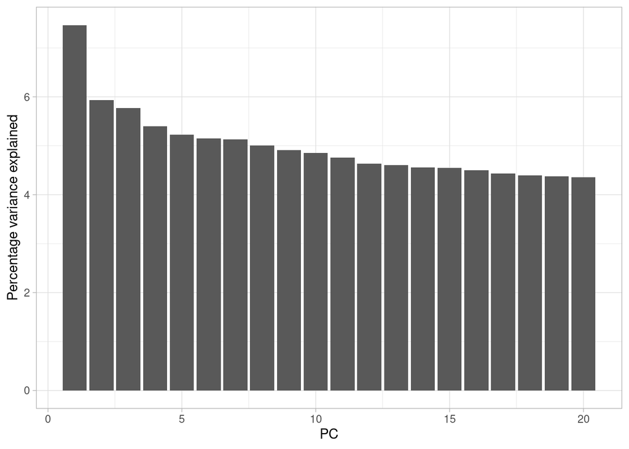

```r
# make plot
a <- ggplot(pve, aes(PC, pve)) + geom_bar(stat = "identity")
a + ylab("Percentage variance explained") + theme_light()
```

```r
# calculate the cumulative sum of the percentage variance explained
cumsum(pve$pve)
```

```
##  [1]   7.465619  13.394671  19.161929  24.557979  29.780321  34.928621
##  [7]  40.060380  45.070750  49.978382  54.830240  59.590617  64.224944
## [13]  68.827568  73.386403  77.931908  82.432207  86.868239  91.265626
## [19]  95.644503 100.000000
```

Plot PCA

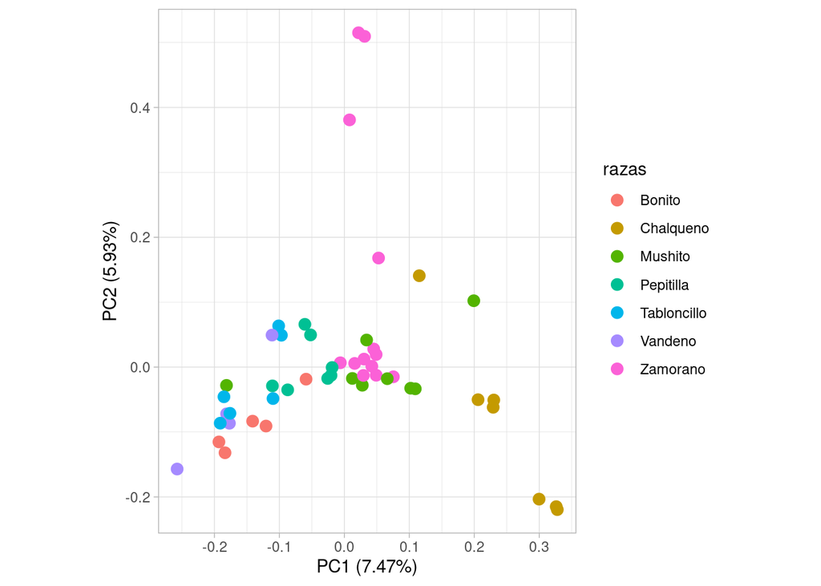

```r
# plot pca
b <- ggplot(pca, aes(PC1, PC2, col = razas)) + geom_point(size = 3)

b <- b + coord_equal() + theme_light()
b + xlab(paste0("PC1 (", signif(pve$pve[1], 3), "%)")) + ylab(paste0("PC2 (", signif(pve$pve[2], 3), "%)"))
```